# **Welcome to the Regression Challenge!**

This notebook provides you some code to setup a Regression problem. There is no optimal solutions, there are many good answers. We only want to see if you know how to tackle the problem. There is a lot of room for your approach to the problem.

Goal: We want you to predict the number of **sales_per_day** (= label) with the given dataset.

Short explanation of the dataset:

- **outlet_id**: The ID of a outlet/market
- **country**: The country in which the outlet is located
- **brand**: "A" or "B"
- **customers_per_day**: The number of customers per day in this outlet
- **sales_per_day**: The amount of sales for a specific outlet on a specific day
- **currency**: The currency of **sales_per_day**
- **week_id**: Calendar week
- **weekday**: mon = Monday, tue = Tuesday, ... , sun = Sunday

```python
import pandas as pd
import numpy as np
import matplotlib.pyplot as plt
import seaborn as sns
from sklearn import preprocessing
import sklearn.model_selection as ms
from sklearn import linear_model
import sklearn.metrics as sklm

%matplotlib inline
```

```python
data_path = 'data.csv' # maybe you have to modify this...
data = pd.read_csv(data_path, sep=';')
data.head(20)
```

|  | brand | country | currency | customers_per_day | outlet_id | sales_per_day | week_id | weekday |
| --- | --- | --- | --- | --- | --- | --- | --- | --- |
| 0 | B | italy | EUR | 189 | 1409 | 379096.25 | 33 | tue |
| 1 | B | greece | EUR | 271 | 896 | 543629.95 | 14 | wed |
| 2 | A | spain | EUR | 73 | 1020 | 146267.66 | 20 | mon |
| 3 | A | austria | EUR | 450 | 665 | 900724.81 | 2 | sat |
| 4 | A | austria | EUR | 441 | 727 | 882991.20 | 18 | sat |
| 5 | A | france | EUR | 284 | 1336 | 569423.85 | 18 | thu |
| 6 | A | greece | EUR | 220 | 803 | 441903.04 | 16 | sat |
| 7 | A | france | EUR | 83 | 1209 | 167430.28 | 8 | tue |
| 8 | B | germany | EUR | 463 | 262 | 927358.13 | 17 | fri |
| 9 | A | germany | EUR | 310 | 182 | 621599.16 | 10 | tue |
| 10 | B | greece | EUR | 190 | 903 | 381543.60 | 44 | thu |
| 11 | A | italy | EUR | 252 | 1547 | 504629.06 | 29 | tue |
| 12 | B | greece | EUR | 167 | 896 | 335325.09 | 13 | thu |
| 13 | B | switzerland | CHF | 0 | 449 | 0.00 | 23 | sun |
| 14 | A | france | EUR | 164 | 1336 | 328803.76 | 46 | wed |
| 15 | A | switzerland | CHF | 376 | 302 | 752681.89 | 4 | wed |
| 16 | B | germany | EUR | 0 | 262 | 0.00 | 29 | sun |
| 17 | B | france | EUR | 320 | 1305 | 641806.39 | 37 | fri |
| 18 | B | germany | EUR | 453 | 219 | 907247.43 | 23 | sat |
| 19 | B | greece | EUR | 107 | 845 | 215432.47 | 29 | mon |

```python
data.shape
```

```
(44100, 8)
```

# Challenge

Now it is your turn. Show us how you are tackeling this problem. You have complete freedom what you do.

## Exploration and Preparation

You have complete freedom what to do. The goal here is to explore the data with e.g. statistics and plots.

```python
# TODO ... Python coding ...
data.dtypes
```

```
brand                 object
country               object
currency              object
customers_per_day      int64
outlet_id              int64
sales_per_day        float64
week_id                int64
weekday               object
dtype: object
```

**todo**: Columns to be converted or transformed:

- to category: **outlet_id**, **brand**, **country**, **currency**, **weekday**, **week_id**
- add level: weekday

Other features are in reasonable data types, and the label **sales_per_day** is numeric.

```python
# convert data type
def to_categories(data, cols):
    """
    convert column in cols to type category
    """
    for col in cols:
        data[col] = data[col].astype("category")

cols = ["outlet_id", "brand", "country", "currency", "weekday", "week_id"]
to_categories(data, cols)
```

```python
data.dtypes
```

```
brand                category
country              category
currency             category
customers_per_day       int64
outlet_id            category
sales_per_day         float64
week_id              category
weekday              category
dtype: object
```

```python
data.info()
```

```
<class 'pandas.core.frame.DataFrame'>
RangeIndex: 44100 entries, 0 to 44099
Data columns (total 8 columns):
 #   Column             Non-Null Count  Dtype
---  ------             --------------  -----
 0   brand              44100 non-null  category
 1   country            44100 non-null  category
 2   currency           44100 non-null  category
 3   customers_per_day  44100 non-null  int64
 4   outlet_id          44100 non-null  category
 5   sales_per_day      44100 non-null  float64
 6   week_id            44100 non-null  category
 7   weekday            44100 non-null  category
dtypes: category(6), float64(1), int64(1)
memory usage: 999.3 KB
```

```python
# add level to weekday
def level_categories(data, col, level):
    """
    add level to col in data
    """
    data[col] = data[col].astype("category")
    data[col] = data[col].cat.reorder_categories(level)


weekday_level = ["mon", "tue", "wed", "thu", "fri", "sat", "sun"]
level_categories(data, "weekday", weekday_level)
```

Until now, the variables in the dataset are in reasonable types.

```python
label = "sales_per_day"
cat_cols = ["brand", "country", "currency", "outlet_id", "weekday", "week_id"]
num_cols = ["customers_per_day"]
```

**numeric variables**: Explore the numeric variables with summary statistics

```python
data.describe()
```

|  | customers_per_day | sales_per_day |
| --- | --- | --- |
| count | 44100.000000 | 4.410000e+04 |
| mean | 226.128934 | 4.531153e+05 |
| std | 156.255404 | 3.127171e+05 |
| min | 0.000000 | 0.000000e+00 |
| 25% | 97.000000 | 1.954732e+05 |
| 50% | 221.000000 | 4.424060e+05 |
| 75% | 344.000000 | 6.880994e+05 |
| max | 664.000000 | 1.329990e+06 |

From the information above, we can see that the label value, sales_per_day, there is a slight difference between the mean and the median values. The median is less than the mean, this indicates that the distribution is right-skewed, which has a tail stretching toward the right.

The large amount of rows with 0 customer cannot be ignored in the dataset, it might be holidays or sundays.

**categorical variable**: Explore the categorical variables with **frequency table**, in order to understand the distributions of them.

```python
def count_unique(data, cat_cols):
    for col in cat_cols:
        print('\n' + 'Categorical column ' + col)
        print(data[col].value_counts())

count_unique(data, cat_cols)
```

```
Categorical column brand
B    22050
A    22050
Name: brand, dtype: int64

Categorical column country
switzerland    6300
spain          6300
italy          6300
greece         6300
germany        6300
france         6300
austria        6300
Name: country, dtype: int64

Categorical column currency
EUR    37800
CHF     6300
Name: currency, dtype: int64

Categorical column outlet_id
1563    315
554     315
629     315
611     315
607     315
       ...
1127    315
1154    315
1161    315
1173    315
117     315
Name: outlet_id, Length: 140, dtype: int64

Categorical column weekday
sun    6300
sat    6300
fri    6300
thu    6300
wed    6300
```

[output cut: 36 more lines]

```
38    980
37    980
36    980
35    980
34    980
33    980
32    980
31    980
30    980
29    980
28    980
27    980
26    980
2     980
Name: week_id, dtype: int64
```

```python
def change_to_euro(cols):
    cur = cols[0]
    sales = cols[1]
    if cur == "CHF":
        return sales*0.88 #change CHF to Euro
    else:
        return sales

data['sales_per_day'] = data[['currency','sales_per_day']].apply(change_to_euro,axis=1)
```

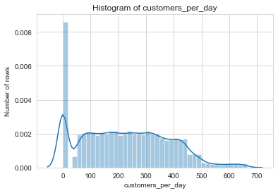

```python
def plot_kde_hist(data, cols, bins = 10, hist = False):
    """
    plot kde of the columns cols of dataframe data. kde is a smoothed version of a histogram.
    sns is used here to set the style of the grid and plot histogram.
    """
    for col in cols:
        sns.set_style("whitegrid")
        sns.distplot(data[col], bins = bins, rug=False, hist = hist)
        plt.title('Histogram of ' + col)
        plt.xlabel(col)
        plt.ylabel('Number of rows')
        plt.show()

plot_kde_hist(data, num_cols, 40, hist = True)
```

There are large amount of observations with sales value of 0. Filter them, and we get a histgram plot with clearer information.

```python
data_filtered = data[data.sales_per_day > 0]
```

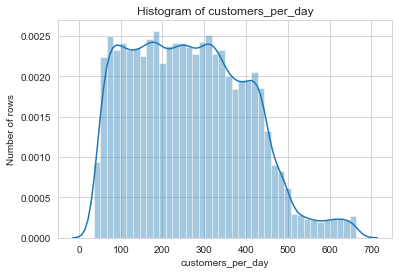

```
Skew is: 0.20618250954932005
Kurtosis: -0.902712
```

```python
plot_kde_hist(data_filtered, num_cols, 40, hist = True)

print ("Skew is:", data_filtered.sales_per_day.skew())
print("Kurtosis: %f" % data_filtered.sales_per_day.kurt())
```

The label sales_per_day has a right-skewed, not normal distribution with some multimodal tendency. The skewness will affect the statistical of machine learning model.

Let's try some feature engineering approach to make it closer to normal, so that it has better performance in modelling.

**transforming numeric variables**: log transformation of sales_per_day

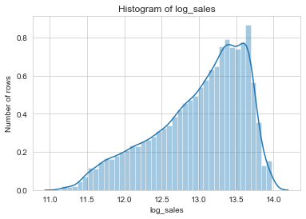

```python
data_filtered['log_sales'] = np.log(data_filtered['sales_per_day'])
plot_kde_hist(data_filtered, ['log_sales'], 40, hist = True)
```

Let's dive into the rows which has 0 sales_per_day, we can see that it only happens on sunday.

```python
data_zero = data[data.sales_per_day == 0]
count_unique(data_zero, cat_cols)
```

```
Categorical column brand
B    3150
A    3150
Name: brand, dtype: int64

Categorical column country
switzerland    900
spain          900
italy          900
greece         900
germany        900
france         900
austria        900
Name: country, dtype: int64

Categorical column currency
EUR    5400
CHF     900
Name: currency, dtype: int64

Categorical column outlet_id
1563    45
554     45
629     45
611     45
607     45
        ..
1127    45
1154    45
1161    45
1173    45
117     45
Name: outlet_id, Length: 140, dtype: int64

Categorical column weekday
sun    6300
sat       0
fri       0
thu       0
wed       0
```

[output cut: 36 more lines]

```
38    140
37    140
36    140
35    140
34    140
33    140
32    140
31    140
30    140
29    140
28    140
27    140
26    140
2     140
Name: week_id, dtype: int64
```

- Scatter plots

To examine the relationship between the features and the label, sales_per_day.

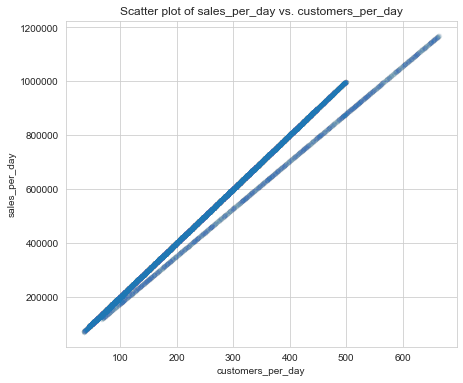

```python
def plot_scatter(data, cols, col_y = label):
    for col in cols:
        fig = plt.figure(figsize=(7,6)) # define plot area
        ax = fig.gca() # define axis
        data.plot.scatter(x = col, y = col_y, ax = ax, alpha = 0.01)
        ax.set_title('Scatter plot of ' + col_y + ' vs. ' + col) # Give the plot a main title
        ax.set_xlabel(col) # Set text for the x axis
        ax.set_ylabel(col_y)# Set text for y axis
        plt.show()

cols = ["customers_per_day"]
plot_scatter(data_filtered, cols)
```

```python
numeric_features = data.select_dtypes(include=[np.number])
numeric_features.dtypes
```

```
customers_per_day      int64
sales_per_day        float64
dtype: object
```

```python
corr = numeric_features.corr()
corr
```

|  | customers_per_day | sales_per_day |
| --- | --- | --- |
| customers_per_day | 1.000000 | 0.995458 |
| sales_per_day | 0.995458 | 1.000000 |

### box plot

To examine the relationship between the categorical features and the label, some box plots are necessary.

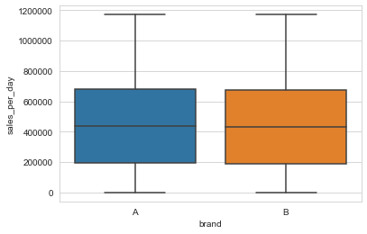

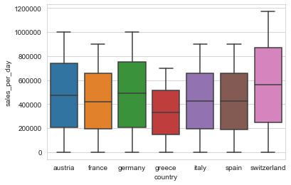

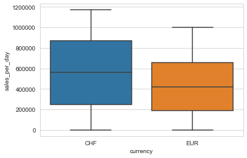

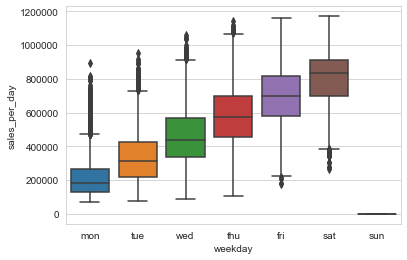

```python
def plot_box(data, cols, col_y = label):
    for col in cols:
        sns.set_style("whitegrid")
        sns.boxplot(col, col_y, data=data)
        plt.xlabel(col) # Set text for the x axis
        plt.ylabel(col_y)# Set text for y axis
        plt.show()

cols = ['brand', 'country', 'currency',  'weekday']
plot_box(data, cols)
```

Notice that for some of these cases, there are some noticeable differences between the sales per day by category. For example, for weekday, there are noticeable increase by weekday and 0 on sundays.

## Modelling

Choose a suitable model for the Regression task or do some statistics. For training you can use TensorFlow, Keras, Pytorch, scikit-learn or something like that.

**one hot encoding**: prepare dummy variables from categorical features

```python
num_cols
```

```
['customers_per_day']
```

```python
cat_cols
```

```
['brand', 'country', 'currency', 'outlet_id', 'weekday', 'week_id']
```

```python
data.head()
```

|  | brand | country | currency | customers_per_day | outlet_id | sales_per_day | week_id | weekday |
| --- | --- | --- | --- | --- | --- | --- | --- | --- |
| 0 | B | italy | EUR | 189 | 1409 | 379096.25 | 33 | tue |
| 1 | B | greece | EUR | 271 | 896 | 543629.95 | 14 | wed |
| 2 | A | spain | EUR | 73 | 1020 | 146267.66 | 20 | mon |
| 3 | A | austria | EUR | 450 | 665 | 900724.81 | 2 | sat |
| 4 | A | austria | EUR | 441 | 727 | 882991.20 | 18 | sat |

```python
from sklearn.preprocessing import LabelEncoder

def cat_encoding(data, IDcols, strCols, catCols):
    le = LabelEncoder()

    for IDcol in IDcols:
    #New variable id col
        data['id_'+ IDcol] = le.fit_transform(data[IDcol])
    new_IDcols = [('id_' + i) for i in IDcols]

    for strCol in strCols:
        if strCol in IDcols:
            strCol = 'id_' + strCol
        data[strCol] = le.fit_transform(data[strCol])

    #Dummy Variables, one-hot encoder
    #cat_cols = ['brand', 'country', 'outlet', 'day', 'week']
    cat_cols = catCols + new_IDcols
    data = pd.get_dummies(data, columns = cat_cols)
    return data
    #data.dtypes
```

save prepared dataset for further reuse.

```python
ID_cols = ['outlet_id', 'week_id', 'weekday']
cat_cols = ['brand', 'country']
str_cols = ["brand", "country", "weekday"]
data = cat_encoding(data, ID_cols, str_cols, cat_cols)
data.dtypes
```

```
currency             category
customers_per_day       int64
outlet_id            category
sales_per_day         float64
week_id              category
                       ...
id_weekday_2            uint8
id_weekday_3            uint8
id_weekday_4            uint8
id_weekday_5            uint8
id_weekday_6            uint8
Length: 207, dtype: object
```

```python
import sys
#Drop unnecessary columns:
data.drop(['currency'],axis=1,inplace=True)

#Export f iles as modified versions:
data.to_csv(sys.path[0]+"/data/prepared.csv",index=False)
```

## split dataset

```python
prepared = pd.read_csv(sys.path[0]+"/data/prepared.csv")
```

```python
train, test = ms.train_test_split(prepared, test_size = 0.2)
```

```python
from sklearn.model_selection import cross_val_score
from sklearn import metrics

def modelfit(alg, dtrain, dtest, predictors, target):
    #Fit the algorithm on the data
    alg.fit(dtrain[predictors], dtrain[target])

    #Predict training set:
    dtrain_predictions = alg.predict(dtrain[predictors])

    #Remember the target had been normalized
    #Sq_train = (dtrain[target])**2
    #Perform cross-validation:
    cv_score = cross_val_score(alg, dtrain[predictors], dtrain[target] , cv=20, scoring='neg_mean_squared_error')
    cv_score = np.sqrt(np.abs(cv_score))

    #Print model report:
    print("\nModel Report")
    print("RMSE : %.4g" % np.sqrt(metrics.mean_squared_error((dtrain[target]).values, dtrain_predictions)))
    print("CV Score : Mean - %.4g | Std - %.4g | Min - %.4g | Max - %.4g" % (np.mean(cv_score),np.std(cv_score),np.min(cv_score),np.max(cv_score)))

    return alg
```

```python
#Define target and ID columns:
target = 'sales_per_day'
#predicted = 'predicted_sales'
IDcols = ['week_id', 'weekday', 'outlet_id']
predictors = train.columns.drop(['sales_per_day','week_id', 'weekday','outlet_id'])
```

### Linear Regression

```python
from sklearn.linear_model import LinearRegression
LR = LinearRegression(normalize=True)
modelfit(LR, train, test, predictors, target)
```

```
Model Report
RMSE : 1.548e+04
CV Score : Mean - 1.543e+04 | Std - 531.6 | Min - 1.481e+04 | Max - 1.619e+04
```

```
LinearRegression(copy_X=True, fit_intercept=True, n_jobs=None, normalize=True)
```

### Ridge Regression

```python
from sklearn.linear_model import Ridge
RR = Ridge(alpha=0.05,normalize=True)
modelfit(RR, train, test, predictors, target)
```

```
Model Report
RMSE : 2.763e+04
CV Score : Mean - 2.777e+04 | Std - 665 | Min - 2.648e+04 | Max - 2.937e+04
```

```
Ridge(alpha=0.05, copy_X=True, fit_intercept=True, max_iter=None,
      normalize=True, random_state=None, solver='auto', tol=0.001)
```

### Decision Tree Model

```python
from sklearn.tree import DecisionTreeRegressor
DT = DecisionTreeRegressor(max_depth=15, min_samples_leaf=100)
modelfit(DT, train, test, predictors, target)
```

```
Model Report
RMSE : 4223
CV Score : Mean - 4675 | Std - 567.3 | Min - 4055 | Max - 6266
```

```
DecisionTreeRegressor(ccp_alpha=0.0, criterion='mse', max_depth=15,
                      max_features=None, max_leaf_nodes=None,
                      min_impurity_decrease=0.0, min_impurity_split=None,
                      min_samples_leaf=100, min_samples_split=2,
                      min_weight_fraction_leaf=0.0, presort='deprecated',
                      random_state=None, splitter='best')
```

### Random Forrest Model

```python
from sklearn.ensemble import RandomForestRegressor
RF = RandomForestRegressor(n_estimators=10,max_depth=15, min_samples_leaf=100)
modelfit(RF, train, test, predictors, target)
```

```
Model Report
RMSE : 7407
CV Score : Mean - 7807 | Std - 403.8 | Min - 7034 | Max - 8967
```

```
RandomForestRegressor(bootstrap=True, ccp_alpha=0.0, criterion='mse',
                      max_depth=15, max_features='auto', max_leaf_nodes=None,
                      max_samples=None, min_impurity_decrease=0.0,
                      min_impurity_split=None, min_samples_leaf=100,
                      min_samples_split=2, min_weight_fraction_leaf=0.0,
                      n_estimators=10, n_jobs=None, oob_score=False,
                      random_state=None, verbose=0, warm_start=False)
```

### xgboost model

```python
from xgboost import XGBRegressor
def xgboost_model(train, test, target, predictors):
    print("\nXgboost Regression")
    my_model = XGBRegressor(n_estimators=1000, learning_rate=0.05)
    my_model.fit(train[predictors], train[target], early_stopping_rounds=5,
                 eval_set=[(test[predictors], test[target])], verbose=False)

    #Predict training set:
    train_df_predictions = my_model.predict(train[predictors])

    print("RMSE : %.4g" % np.sqrt(metrics.mean_squared_error((train[target]).values, train_df_predictions)))

    return my_model
```

```python
xgbmodel = xgboost_model(train, test, target, predictors)
```

```
Xgboost Regression
RMSE : 601
```

Do model selection on filtered dataset which removed records with sales_per_day = 0

```python
data_filtered = cat_encoding(data_filtered, ID_cols, str_cols, cat_cols)
data_filtered.drop(['currency'],axis=1,inplace=True)
train_f, test_f = ms.train_test_split(data_filtered, test_size = 0.2)
```

```python
predictors_f = train_f.columns.drop(['sales_per_day','week_id', 'weekday','outlet_id'])

target = 'sales_per_day'
IDcols = ['week_id', 'weekday', 'outlet_id']
filename = '/filtered'

xgbmodel_f = xgboost_model(train_f, test_f, target, predictors_f)
```

```
Xgboost Regression
RMSE : 238.8
```

From the model selction on filtered dataset, we can see, the performance improved a lot. Therefore we can use some external public dataset such as sunday or public holiday to predict the sales for them, namely, 0 when it is sunday or public holiday.

## Evaluation & Outlook

After finishing your training take a look at sample predictions and analyse strengths and weeknesses of your model.

What could be next steps to improve the model?

- harness some public dataset of public holiday or date to predict the sales on sundays or holidays.
- clustering the outlets and do regression on each cluster to get better performance.
- try time series prediction techniques like vector auto regression or RNN such as LSTM on sales_per_day
- Last but not the least, stick to simple model to have better interpretability and prevent overfitting

```python
import sklearn.metrics as sklm
import math

def print_metrics(y_true, y_predicted):
    ## First compute R^2 and the adjusted R^2
    #r2 = sklm.r2_score(y_true, y_predicted)
    #r2_adj = r2 - (n_parameters - 1)/(y_true.shape[0] - n_parameters) * (1 - r2)

    ## Print the usual metrics and the R^2 values
    print('Mean Square Error      = ' + str(sklm.mean_squared_error(y_true, y_predicted)))
    print('Root Mean Square Error = ' + str(math.sqrt(sklm.mean_squared_error(y_true, y_predicted))))
    print('Mean Absolute Error    = ' + str(sklm.mean_absolute_error(y_true, y_predicted)))
    print('Median Absolute Error  = ' + str(sklm.median_absolute_error(y_true, y_predicted)))
```

```python
y_score = xgbmodel.predict(test[predictors])
print_metrics(test['sales_per_day'], y_score)
```

```
Mean Square Error      = 399055.8631247162
Root Mean Square Error = 631.7086853326589
Mean Absolute Error    = 481.5975691921799
Median Absolute Error  = 431.6600000000326
```

```python
y_score_f = xgbmodel_f.predict(test_f[predictors_f])
print_metrics(test_f['sales_per_day'], y_score_f)
```

```
Mean Square Error      = 73354.11669133516
Root Mean Square Error = 270.8396512539018
Mean Absolute Error    = 195.94167152612414
Median Absolute Error  = 142.36437500000466
```